# The Endless Best/Worst Drivers Debate

Madeleine Guettler

**Introduction**

In general the conversation of who is a good driver vs. bad driver comes up at least once in one’s lifetime of conversations. In my experience there tends to be a wide variety of opinions where in my experience one is quick to defend one’s own city of drivers but when discussing with others their experiences with driving they are quick to argue that actually driving in your city is an absolute nightmare. So this leads to the question of what area really is the best place to drive and which is the worst.

In an effort to look into this question a data set I looked into was a data frame given in the `fivethirtyeight` package that contained the data frame named `bad_drivers` which is a representation of the 50 states plus D.C. in the U.S.. This data is taken from the National Highway Traffic Safety Administration 2012, National Highway Trafic Safety Administration 2009 & 2012, and the National Association of Insurance Commissioners 2010 & 2011. The data frame included 8 different variables: 1. `State`: State in U.S. 2. `num_drivers`: Number of drivers involved in fatal collisions per billion miles 3. `perc_speeding`: Percentage of drivers involved in fatal collisions who were speeding 4. `perc_alcohol`: Percentage of drivers involved in fatal collisions who were alcohol-impaired 5. `perc_no_previous`: Percentage of drivers involved in fatal collisions who had not been involved in any previous accidents 6. `insurance_premiums`: Car insurance premiums 7. `losses`: Losses incurred by insurance companies for collisions per insured driver

Upon looking at the data, in an effort to make the analysis more conducive I chose to focus my attention to one specific region. In this case the region I chose were the six New England States Maine, New Hampshire, Vermont, Massachusetts, Rhode Island, and Connecticut. While on first inspection simply looking at the number of drivers involved in fatal accidents per billion miles it would be easy to come to the conclusion that the state with the best drivers was the state with the fewest cases which in this case would be Massachusetts and the state with the worst drivers based off the most cases was Maine. Unfortunately, it becomes more complicated when investigating the causes of the fatal collisions. Overall it’s hard to come to fully accurate conclusion of best vs. worst drivers in these six states and in general because there are also variables in play that could have caused the collisions that are not necessarily documented such as weather conditions, length of driving at time of accident, young driver vs. older driver, driving culture in state, location (highway vs. urban streets), or car maintenance conditions. However, the data does allow some interesting questions to be thought about.

**Code Needed for Data Analysis**

```r
# Load any R Packages you may need
library(tidyverse)
library(dplyr)
library(fivethirtyeight)
```

**First Graphic**

In looking at the first graphic to explore the data you can draw some basic information from the states. I chose as a starting out point a very basic graphic. I chose to create a column graph simply because it provided an easier visualization to the data then for example using a scatterpoint graph that while providing the same information didn’t create as clear of a contrast in the different values upon first glance. The x variable is mapped to the variable `state` so each column in the graph represents a different state; the y variable is mapped to the `num_drivers` variable which gives a visualization of the number of fatal collisions per billion miles, so the higher the column the more collisions there were per billion miles.

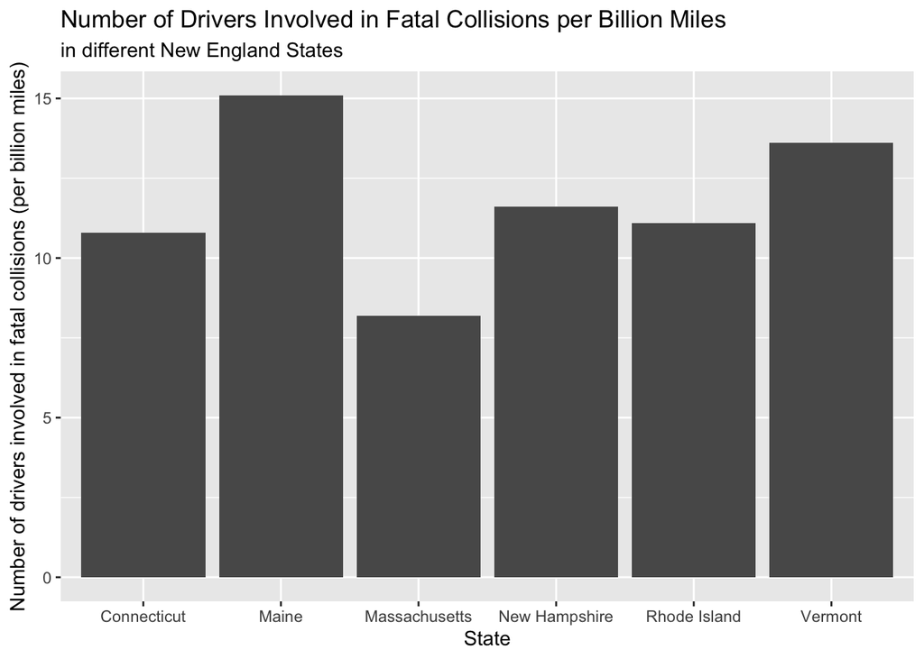

```r
ggplot(bad_drivers_NE, aes(x = state, y = num_drivers)) +
  geom_col() +
  labs(title = "Number of Drivers Involved in Fatal Collisions per Billion Miles",
       subtitle = "in different New England States",
       x = "State",
       y = "Number of drivers involved in fatal collisions (per billion miles)")
```

After looking at the graph of the six New England states a few main things pop out. First is that Massachusetts has the lowest number of fatal collisions per billion miles with a value of 8.2 per billion miles and the second is that Maine has the highest number of fatal collisions with a value of 15.1. From there you can tell that Connecticut, New Hampshire, Rhode Island have a fairly close number of fatal collisions, where Connecticut has a value of 10.8 fatal collisions per billion miles, Rhode Island has a value of 11.1 fatal collisions per billion miles, and New Hampshire which has a value of 11.6 fatal collisions per billion miles. And finally, Vermont has the second highest fatal collisions per billion miles with a value of 13.6. Some other things to note is that Massachusetts has almost half the cases of the highest value state Maine. So upon first glance it is very easy to conclude that Massachusetts seems to have the best drivers and Maine the worst at least in the New England region.

**Next Series of Graphs to Go Deeper into Analysis**

These next following graphs are a slightly more in depth view of the background behind the fatal collisions.When I personally think about top reasons for possible fatal collisions that could result from being a bad or responsible driver I generally think alcohol impairment, distractions, and speeding, so the next two graphs explore these three variables. According to article *What Are the Most Common Car Accident Fatalities* (https://www.idrivesafely.com/defensive-driving/trending/most-common-car-accident-fatalities) the leading causes of fatal car accidents is distracted driving and other big contributors is excessive driving and alcohol use. Since there is no data in this data set on fatal collisions due to distracted driving and speeding and alcohol are high contributors to collisions, the next two graphs focus on percentage of fatal collisions due to speeding and alcohol use.

**Second Graph Based Off of States, Number of Fatal Collisions, and Percentage of Speeding Related Collisions**

This first graph still has the variables state and number of fatal collisions per billion miles but adds in the variable `perc_speeding`. So as previously the x variable is mapped to the different states, the y variable mapped to the number of collisions per billion miles, and the final variable percentage speeding related collisions is mapped to the aesthetic fill which is seen in the graphic as the different color shades.

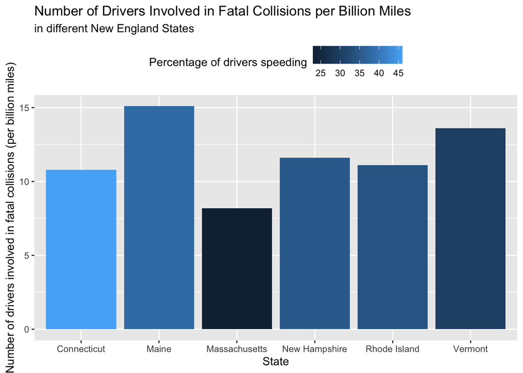

```r
ggplot(bad_drivers_NE, aes(x = state, y = num_drivers)) +
  geom_col(aes(fill = perc_speeding)) +
  labs(title = "Number of Drivers Involved in Fatal Collisions per Billion Miles",
       subtitle = "in different New England States",
       x = "State",
       y = "Number of drivers involved in fatal collisions (per billion miles)",
       fill = "Percentage of drivers speeding") +
   theme(legend.position = "top")
```

Upon looking at this new graph one can still conclude that Massachusetts holds up for potentially being the best drivers out of all six states because Massachusetts has the lowest percentage of fatal collisions due who were speeding with a value of 23. Where it gets more complicated though is that actually the highest state having collisions due to speeding is not Maine but Connecticut wiht a value of 46 so twice as much as Massachusetts which is surprising due to Connecticut actually having the second lowest total fatal collisions per billion miles. One can argue though that Maine still stands in it’s place for worst driving as Maine has the second highest fatal collisions related to speeding with a value of 38.

**Third Graph Based Off of States, Number of Fatal Collisions, and Percentage of Alcohol Related Collisions**

In this next graphic we once again still have the variables state and number of fatal collisions per billion miles but this time adds in the variable `perc_alcohol`. So as previously the x variable is mapped to the different states, the y variable mapped to the number of collisions per billion miles, and the final variable percentage alcohol related collisions is mapped to the aesthetic fill which is seen in the graphic as the different color shades

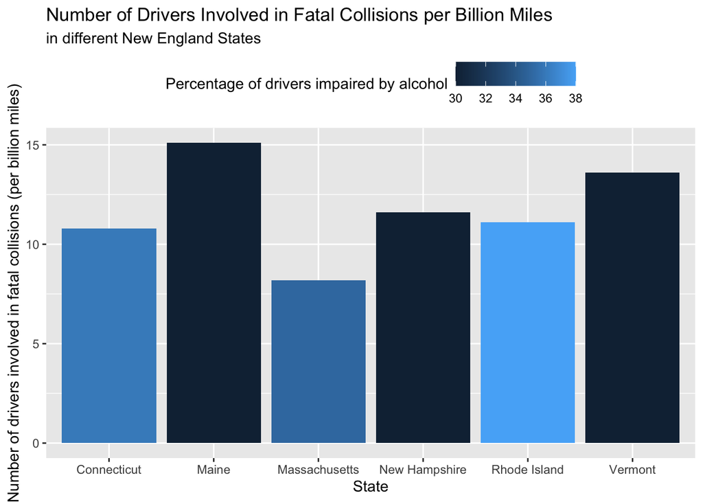

```r
ggplot(bad_drivers_NE, aes(x = state, y = num_drivers)) +
  geom_col(aes(fill = perc_alcohol)) +
  labs(title = "Number of Drivers Involved in Fatal Collisions per Billion Miles",
       subtitle = "in different New England States",
       x = "State",
       y = "Number of drivers involved in fatal collisions (per billion miles)",
       fill = "Percentage of drivers impaired by alcohol") +
   theme(legend.position = "top")
```

This graphic puts an interesting turn of events due to the three states with the highest recorded fatal collisions actually having the lowest number of alcohol impairment related collisions where all three states Maine, Vermont, and New Hamphire having in relation to alcohol impairment related collisions the lowest value of 30. Now of the three remaining states while Massachusetts has the lowest value of 35 so not the worst out of all six states it could still be used in an argument that in fact Massachusetts is not the best drivers state in New England.

**Thought Process Behind Remaining Visualization of Data**

Now that we’ve explored data containing two of the major contributors of fatal collision alcohol and speeding, lets take a look at two factors that could be used to argue that a state is in fact not filled with bad drivers by looking at the data related of collisions not being due to distracted driving and also the data on percentage of individuals who did not have any previous collisions before the fatal collision that was recorded in the data set.

**Fourth Graph Based Off of States, Number of Fatal Collisions, and Percentage of Not Distracted Related Collisions**

This next graphic once again still has the variables state and number of fatal collisions per billion miles but this time adds in the variable `perc_not_distracted`. So as previously the x variable is mapped to the different states, the y variable mapped to the number of collisions per billion miles, and the final variable not distracted related collisions is mapped to the aesthetic fill which is seen in the graphic as the different color shades.

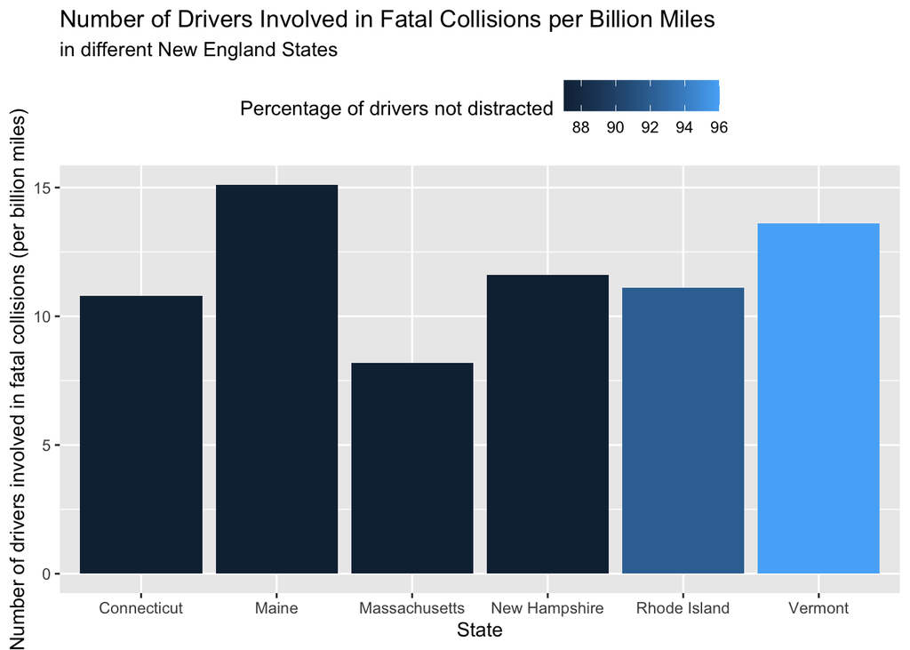

```r
ggplot(bad_drivers_NE, aes(x = state, y = num_drivers)) +
  geom_col(aes(fill = perc_not_distracted)) +
  labs(title = "Number of Drivers Involved in Fatal Collisions per Billion Miles",
       subtitle = "in different New England States",
       x = "State",
       y = "Number of drivers involved in fatal collisions (per billion miles)",
       fill = "Percentage of drivers not distracted") +
   theme(legend.position = "top")
```

So something to note in this graphic off the bat is to not be confused by the color scheme. As in this case the lighter color actually is better than the darker color as the lighter color means there is a higher perentage of drivers who had collisions not related to being distracted. So in looking at the data it is important to note that Connecticut, Maine, Massachusetts, and New Hamphire all had the same percentage value of 87% of collisions being not caused by distracted driving. And interestingly Vermont who can still be seen in this graphic as the second state with the highest level of fatal collision per billion miles actually has the highest percentage of collision not related to distracted driving which is 96%. So it starts to raise the question is Massachusetts really the state with the best drivers and is Maine really the state with the worst drivers.

**Fifth Graph Based Off of States, Number of Fatal Collisions, and Percentage of No Previous History of Collisions**

The last graphic looked at in this blog contains the consistent variables in all of these graphics state and number of fatal collisions per billion miles and adds in the variable `perc_no_previous`. So as previously the x variable is mapped to the different states, the y variable mapped to the number of collisions per billion miles, and the final variable percentage no previous history of collisions is mapped to the aesthetic fill which is seen in the graphic as the different color shades.

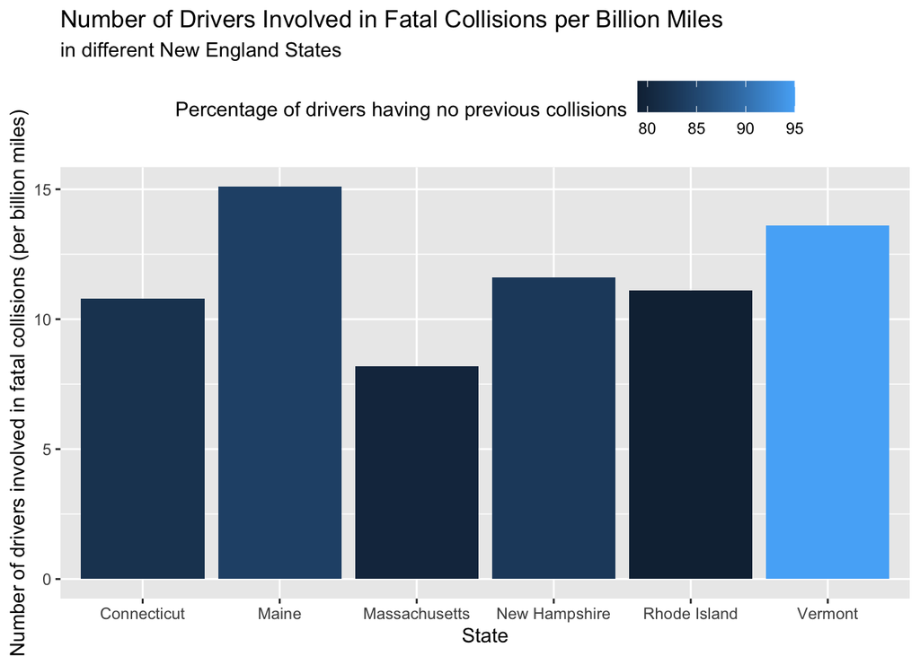

```r
ggplot(bad_drivers_NE, aes(x = state, y = num_drivers)) +
  geom_col(aes(fill = perc_no_previous)) +
  labs(title = "Number of Drivers Involved in Fatal Collisions per Billion Miles",
       subtitle = "in different New England States",
       x = "State",
       y = "Number of drivers involved in fatal collisions (per billion miles)",
       fill = "Percentage of drivers having no previous collisions") +
   theme(legend.position = "top")
```

Once again something to note is that the lighter the color the better. So in this data set, Rhode Island has the worst value of 79% no previous accidents and Massachusetts has the second worst value of 80% no previous accidents. Meanwhile Vermont who as a reminder has the second highest number of fatal accidents has the best percentage value of 95% and Maine has the second best percentage value of 84%. This graphic once again raises the question of whether Massachusetts and Maine are really the states with the best and worst drivers.

Also a side note is that while there would have been other ways to graph these different data variables, the reason that I chose to keep the graphics in column forms and simply documenting the extra variables through color shading was because I wanted to represent the data in the clearest way possible instead of overloading with two many variables in one graphic.

**Final Conclusions**

Based off the last two graphics it raises the question on what other factors are there that are contributing to these fatal collisions as while Massachusetts has the lowest total fatal collisions in terms of it’s driving records of responsible driving meaning not being distracted and also history of no previous collisions as a collective state drivers don’t fair so well in this domain in comparison to the other New England States which raises the question are there other factors contributing to Vermont and Maine’s high collision rates such as weather conditions and could it be that actually Maine and Vermont residents aren’t such bad drivers after all? Personally, I especially have to raise this question as while I have not exactly asked every individual of their driving experiences in all six of these states, in my experience when mentioning driving in a fairly populated city of Massachusetts such as Boston it usually results in groans from fellow friends who have had to drive in Boston and are not natives of Boston as they personally find that Boston drivers have the tendency of being a bit crazy, and even personally despite having grown up in Boston and learned to drive in Boston I also don’t have the fondest memories at times when it comes to driving in the city of Boston.